# Introduction to Python

### part 4 Matplotlib

- 仿 Matlab
- 2D 繪圖

#### 2021/5/5

#### 參考資料

- [炎龍老師的教學研究網](http://yenlung.km.nccu.edu.tw/home/index.php?f=contentShow&id=424)
- [手把手打開 Python 資料分析大門](http://foundation.datasci.tw/py3-data-analysis-171217/)
- https://matplotlib.org/api/_as_gen/matplotlib.pyplot.html
- https://matplotlib.org/tutorials/introductory/pyplot.html
- https://matplotlib.org/contents.html
- https://matplotlib.org/examples/index.html
- [Scipy Lecture Notes](http://www.scipy-lectures.org/index.html)
- [SciPy Cookbook](http://scipy-cookbook.readthedocs.io/index.html)
- [Matplotlib cheatsheets](https://github.com/matplotlib/cheatsheets#cheatsheets)

## 快速查詢表、筆記

[figure not shown]

# Matplotlib

- 2D 繪圖
  - `% matplotlib inline` 在jupyter notebook 模式需加入這行
  - `import matplotlib.pyplot as plt`
  - 或 `from matplotlib import pyplot as plt`
  - `plt.plot(x,y,.........)` 畫出 y 對 x 的圖
  - `plt.show()` 開啟圖片編輯視窗，並將圖顯示在該視窗中，透過該視窗可修改圖片、存檔

    在jupyter notebook 不需這行

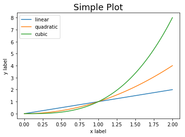

```python
##  第一次簡單畫  ###

# jupyter notebook 需加入
%matplotlib inline

import numpy as np
import matplotlib.pyplot as plt

# 0 ~ 2 產生100等間距的點
x = np.linspace(0, 2, 100)

# 畫出 y = x、x*x 、 x*x*x，並命名圖例
plt.plot(x, x, label='linear')
plt.plot(x, x**2, label='quadratic')
plt.plot(x, x**3, label='cubic')

plt.xlabel('x label')   # x 軸名稱

plt.ylabel('y label')   # y 軸名稱

plt.title("Simple Plot", fontsize=18)  # 圖形名稱，指定字型大小

plt.legend()  # 標出圖例

#plt.show() # 在此不需要
```

```
 <a list of 3 Text yticklabel objects>)
```

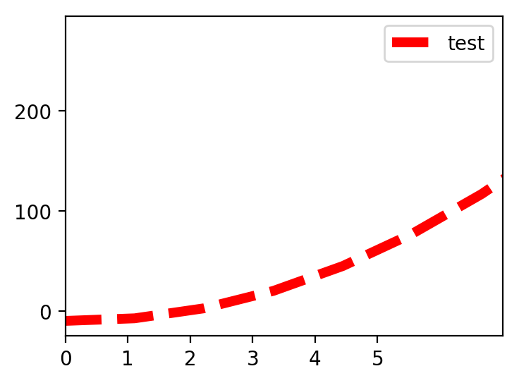

```python
% matplotlib inline

import numpy as np
import matplotlib.pyplot as plt

x = np.linspace(0, 10, 10)
y = 3*x**2 - x - 10

plt.figure(num=1, figsize=(4,3), dpi=200)   # 1號圖，圖的大小為4*3，dpi為200

# 用 紅色虛線 畫，指定線寬
plt.plot(x, y, 'r--',lw=5, label='test')

# 圖例選在最佳的位置
plt.legend(loc='best')

plt.xlim(0,7)              # 設定 x 軸顯示範圍
plt.xticks(np.arange(0,6)) # 設定 x 軸顯示的數字範圍

#plt.ylim(0,300)
plt.yticks([0,100,200])    # 設定 y 軸顯示的數字

# plt.yticks(np.linspace(0,300,10))

# plt.axis([1, 5, 15, 300]) #直接指定x範圍 1~5，y範圍 15~300
```

## 用各種顏色、各種線形

顏色與線形可以混用

[figure not shown]

## 圖例的位置

[figure not shown]

Alternatively can be a 2-tuple giving x, y of the lower-left corner of the legend in axes coordinates (in which case bbox_to_anchor will be ignored).

# 軸線的操作

## 目前所在的 figure 和 axis

`fig = plt.gcf()`

`ax = plt.gca()`

https://matplotlib.org/api/spines_api.html

```
 <a list of 3 Text yticklabel objects>)
```

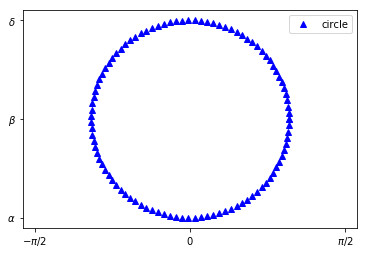

```python
# 參數式

%matplotlib inline

import numpy as np
import matplotlib.pyplot as plt

t = np.linspace(0, 2*np.pi, 100)

x, y = np.cos(t), np.sin(t)

plt.axis('equal') # 各軸等長

plt.plot(x, y, 'b^', lw=5, label='circle')

plt.legend(loc='best')

plt.xticks([-np.pi/2, 0 , np.pi/2],[r'$-\pi/2$', r'$0$', r'$\pi/2$']) # 指定x軸上顯示的數字，並以latex符號表示
                                                                      # 使用latex符號，格式為 r'$    $'
plt.yticks([-1, 0, 1],[r'$\alpha$', r'$\beta$', r'$\delta$'])
```

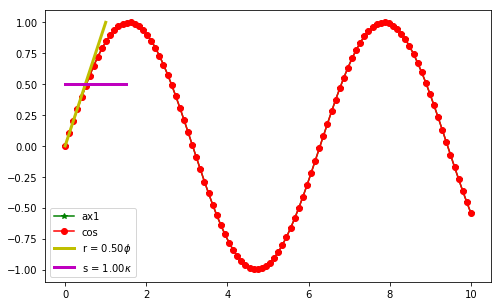

```python
%matplotlib inline

import numpy as np
import matplotlib.pyplot as plt

plt.figure(figsize=(8, 5))

x = np.linspace(0, 10, 100)
y1 = np.sin(x)
y2 = np.cos(x)

sd = 1
rd = 0.5

# 將圖例指定名稱，利用圖軸名稱，不是用label
ax1, = plt.plot(x, y1, 'g-*', )
ax2, = plt.plot(x, y1, 'r-o', )

ax3, = plt.plot([0,sd],[0,1],'-', lw=3, color='y')
ax4, = plt.plot([0,3*rd],[rd,rd],'-', lw=3, color='m')

plt.legend([ax1,ax2,ax3,ax4],['ax1','cos',r'r = $%.2f \phi$' % rd,r's = $%.2f \kappa$' % sd], loc='lower left')
```

## set_color(c)

Set the edgecolor.

## set_bounds(low, high)

Set the bounds of the spine.

## set_position(position)

set the position of the spine

Spine position is specified by a 2 tuple of (position type, amount).

The position types are:

‘outward’ : place the spine out from the data area by the specified number of points. (Negative values specify placing the spine inward.)

‘axes’ : place the spine at the specified Axes coordinate (from 0.0-1.0).

‘data’ : place the spine at the specified data coordinate.Additionally, shorthand notations define a special positions:

‘center’ -> (‘axes’,0.5)

‘zero’ -> (‘data’, 0.0)

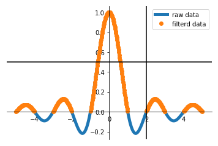

```python
# 利用 array 做資料過濾
%matplotlib inline

import numpy as np
import matplotlib.pyplot as plt

x = np.linspace(-5, 5, 500)
y = np.sinc(x)

# 將函數大於 0 的地方標示出來

plt.plot(x, y, lw =5, label='raw data')
plt.plot(x[y>0], y[y>0], 'o', label='filterd data')

plt.legend(loc='best')

ax = plt.gca()  # get current axis

ax.spines['right'].set_color('none')  # 將右軸的顏色設為無色
ax.spines['top'].set_visible(False)   # 將上軸設為不可見

ax.spines['left'].set_position(('data',0))  #將左軸位置依照資料數值放在 x=0位置
ax.spines['bottom'].set_position(('data',0)) #將左軸位置依照資料數值放在 y=0位置

plt.axhline(0.5, color='k')  #draw a horizontal line at y=0
plt.axvline(2, color='k')
```

## 畫散佈圖

`plt.scatter()`

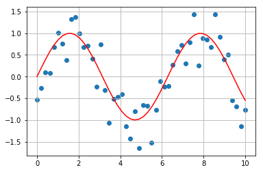

```python
% matplotlib inline

import numpy as np
import matplotlib.pyplot as plt

x = np.linspace(0, 10, 50)

y = np.sin(x) + 0.4*np.random.randn(50)  # 給定sin函數＋隨機分佈

plt.scatter(x, y)
plt.plot(x, np.sin(x),'r')

plt.grid(True)  # 畫出格線
```

參數控制

[figure not shown]

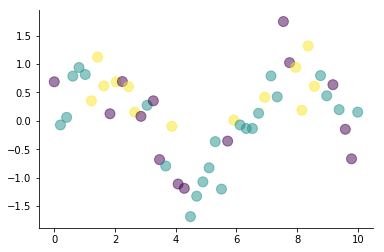

```python
%matplotlib inline

import numpy as np
import matplotlib.pyplot as plt

c = np.random.randint(0, 3, 50)  # 在 0, 1, 2 抽 50 個亂數

x = np.linspace(0, 10, 50)
y = np.sin(x) + 0.4*np.random.randn(50)

fig = plt.scatter(x, y,
            s=100,
            c=c,
            alpha=0.5)  #分三色(0,1,2)，讓程式自己決定

ax = plt.gca()
ax.spines['right'].set_visible(False)
ax.spines['top'].set_visible(False)
```

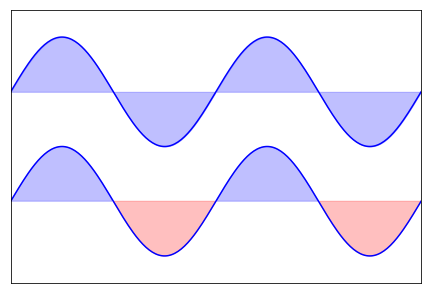

```python
import numpy as np
import matplotlib.pyplot as plt
n = 256
X = np.linspace(-np.pi, np.pi, n, endpoint=True)
Y = np.sin(2 * X)
plt.axes([0.025, 0.025, 0.95, 0.95])
plt.plot(X, Y + 1, color='blue', alpha=1.00)
plt.fill_between(X, 1, Y + 1, color='blue', alpha=.25)
plt.plot(X, Y - 1, color='blue', alpha=1.00)
plt.fill_between(X, -1, Y - 1, (Y - 1) > -1, color='blue', alpha=.25)
plt.fill_between(X, -1, Y - 1, (Y - 1) < -1, color='red', alpha=.25)
plt.xlim(-np.pi, np.pi)
plt.xticks(())
plt.ylim(-2.5, 2.5)
plt.yticks(())
plt.show()
```

## colormap 顏色主題

不同的配色就是用不同的color map，要改就是去設定cmap

https://matplotlib.org/users/colormaps.html

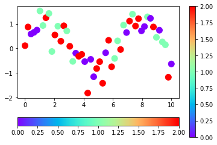

```python
% matplotlib inline

import numpy as np
import matplotlib.pyplot as plt

c = np.random.randint(0, 3, 50)

x = np.linspace(0, 10, 50)
y = np.sin(x) + 0.4*np.random.randn(50)

plt.scatter(x, y, s=100, c=c, cmap='rainbow')

plt.colorbar(orientation='vertical')   # 顏色的強度圖例
plt.colorbar(orientation='horizontal')
```

# 多圖並列

用`subplot`

### subplot(nrows, ncols, index)

[figure not shown]

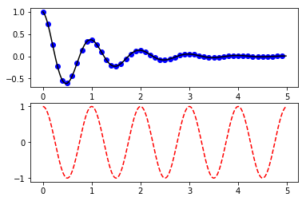

```python
%matplotlib inline

import numpy as np
import matplotlib.pyplot as plt

def f(t):
    return np.exp(-t) * np.cos(2*np.pi*t)

t1 = np.arange(0.0, 5.0, 0.1)
t2 = np.arange(0.0, 5.0, 0.02)

plt.figure(1)    # 1 號圖

plt.subplot(2,1,1)  # 2列 x 1行，序號1
plt.plot(t1, f(t1), 'bo', t2, f(t2), 'k')

plt.subplot(2,1,2) # 2列 x 1行，序號2
plt.plot(t2, np.cos(2*np.pi*t2), 'r--')
```

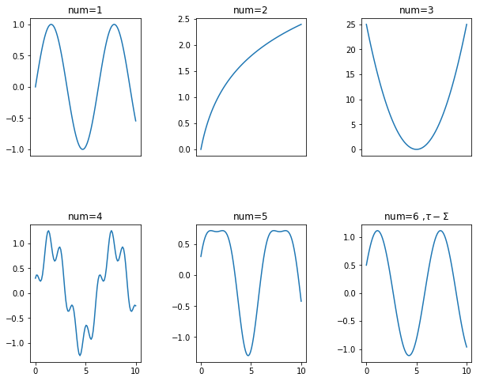

```python
% matplotlib inline

import numpy as np
import matplotlib.pyplot as plt

x = np.linspace(0,10,100)

plt.figure(figsize=(10,8))  #設定整張圖的size


plt.subplot(2,3,1)   # 要畫 2列 x 3 行 的圖，序號 1
plt.plot(x, np.sin(x))
plt.title("num=1")
plt.xticks(())      # 去除 x軸上的數值標示

plt.subplot(2,3,2)   # 序號 2
plt.plot(x, np.log(x+1))
plt.title("num=2")
plt.xticks(())


plt.subplot(2,3,3)   # 序號 3
plt.plot(x, (x-5)**2)
plt.title("num=3")
plt.xticks(())


plt.subplot(2,3,4)  # 序號 4
plt.plot(x, np.sin(x)+0.3*np.cos(5*x))
plt.title("num=4")

plt.subplot(2,3,5)  # 序號 5
plt.plot(x, np.sin(x)+0.3*np.cos(2*x))
plt.title("num=5")

plt.subplot(2,3,6)  # 序號 6
plt.plot(x, np.sin(x)+0.5*np.cos(x))
plt.title(r"num=6 ,$\tau-\Sigma$")

plt.subplots_adjust(hspace=0.5)
plt.subplots_adjust(wspace=0.5)
```

## subplots_adjust

### 對圖的位置作調整

left = 0.125 : the left side of the subplots of the figure

right = 0.9 : the right side of the subplots of the figure

bottom = 0.1 : the bottom of the subplots of the figure

top = 0.9 : the top of the subplots of the figure

wspace = 0.2 : the amount of width reserved for space between subplots, expressed as a fraction of the average axis width

hspace = 0.2 : the amount of height reserved for space between subplots, expressed as a fraction of the average axis height

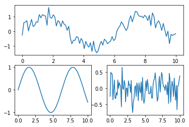

```python
%matplotlib inline

import numpy as np
import matplotlib.pyplot as plt

x = np.linspace(0, 10, 100)

plt.subplot(2,1,1)    # 2列 x 1行，序號1
y1 = np.sin(x) + 0.3*np.random.randn(100)
plt.plot(x, y1)

plt.subplot(2,2,3)   # 2列 x 2行，序號3
y2 = np.sin(x)
plt.plot(x, y2)

plt.subplot(2,2,4)  # 2列 x 1行，序號4
y3 = y1 - y2
plt.plot(x,y3)
```

在 matplotlib的畫圖中，每次都有一個大figure，實際畫的圖是在其中的 axis 上。 而一個 figure可以有很多 axes

[figure not shown]

gca : Get the current Axes instance on the current figure matching the given keyword args, or create one.

gcf : Get a reference to the current figure.

gci : Get the current colorable artist.

cla : Clear the current axes.

clabel: Label a contour plot.

clf : Clear the current figure.

clim : Set the color limits of the current image.

close : Close a figure window.

coher : Plot the coherence between x and y.

colorbar : Add a colorbar to a plot.

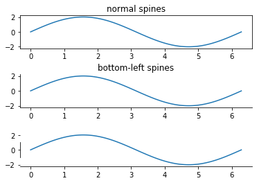

```python
%matplotlib inline

import numpy as np
import matplotlib.pyplot as plt


x = np.linspace(0, 2 * np.pi, 100)
y = 2 * np.sin(x)


#fig = plt.figure()
ax0 = plt.subplot(3, 1, 1)  #將序號 1的圖命名為 ax0

#或者用
#ax0 = plt.add_subplot(3,1,1)

ax0.plot(x, y)
ax0.set_title('normal spines')

ax1 = plt.subplot(3, 1, 2)
ax1.plot(x, y)
ax1.set_title('bottom-left spines')

# Hide the right and top spines
ax1.spines['right'].set_visible(False)
ax1.spines['top'].set_visible(False)
# Only show ticks on the left and bottom spines
ax1.yaxis.set_ticks_position('left')
ax1.xaxis.set_ticks_position('bottom')

ax2 = plt.subplot(3, 1, 3)
ax2.plot(x, y)

# Only draw spine between the y-ticks
ax2.spines['left'].set_bounds(-1, 1)
# Hide the right and top spines
ax2.spines['right'].set_visible(False)
ax2.spines['top'].set_visible(False)
# Only show ticks on the left and bottom spines
ax2.yaxis.set_ticks_position('left')
ax2.xaxis.set_ticks_position('bottom')

# Tweak spacing between subplots to prevent labels from overlapping
plt.subplots_adjust(hspace=0.8)
```

### PS1 :

plt.subplots() is a function that returns a tuple containing a figure and axes object(s). Thus when using `fig, ax = plt.subplot()`

you unpack this tuple into the variables fig and ax. Having fig is useful if you want to change figure-level attributes or save the figure as an image file later (e.g. with `fig.savefig('yourfilename.png'`). You certainly don't have to use the returned figure object but many people do use it later so it's common to see. Also, all axes objects (the objects that have plotting methods), have a parent figure object anyway, thus:

`fig, ax = plt.subplots()`

is more concise than this:

`fig = plt.figure()`

`ax = fig.add_subplot(111)`

### PS2 :

The following question is that what if I want more subplots in the figure?

As mentioned in the Doc, we can use `fig = plt.subplots(nrows=2, ncols=2)`

to set a group of subplots with grid(2,2) in one figure object.

Then as we know, the `fig, ax = plt.subplots()` returns a tuple,

let's try `fig, ax1, ax2, ax3, ax4 = plt.subplots(nrows=2, ncols=2)` firstly.

ValueError: not enough values to unpack (expected 4, got 2)

It raises a error, but no worry, because we now see that plt.subplots() actually returns a tuple with **two elements**.

**The 1st one must be a figure object, and the other one should be a group of subplots objects.**

So let's try this again:

`fig, [[ax1, ax2], [ax3, ax4]] = plt.subplots(nrows=2, ncols=2)`

and check the type:

type(fig) #<class 'matplotlib.figure.Figure'> type(ax1) #<class 'matplotlib.axes._subplots.AxesSubplot'>

Of course, if you use parameters as (nrows=1, ncols=4), then the format should be:

`fig, [ax1, ax2, ax3, ax4] = plt.subplots(nrows=1, ncols=4)`

So just remember to keep the construction of the list as the same as the subplots grid we set in the figure.

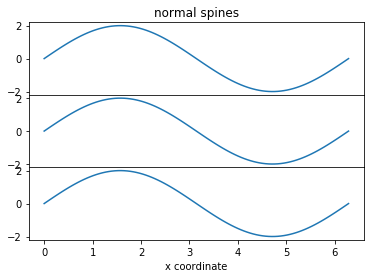

```python
%matplotlib inline

import numpy as np
import matplotlib.pyplot as plt


x = np.linspace(0, 2 * np.pi, 100)
y = 2 * np.sin(x)

# 1張圖，多個 axes，經常使用以下表示
# 之後可以用 fig 存圖檔，用 ax0，操作各個axes
fig, (ax0, ax1, ax2) = plt.subplots(nrows=3)

ax0.plot(x, y)
ax0.set_title('normal spines')

ax1.plot(x, y)

ax2.plot(x, y)

plt.xlabel('x coordinate')

plt.subplots_adjust(hspace=0.0)   # 共用水平軸座標
```

運用以上的概念，可以畫出一個圖中又有小圖

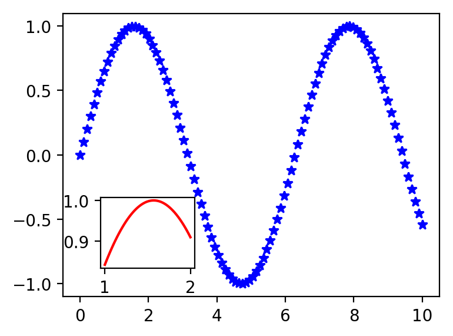

```python
%matplotlib inline

import numpy as np
import matplotlib.pyplot as plt

plt.figure(figsize=(4,3),dpi=200)

plt.axes([0.1, 0.1, 0.8, 0.8])  #左下角座標(0.1, 0.1)，右上角座標(0.8, 0.8)
x = np.linspace(0, 10, 100)
y = np.sin(x)
plt.plot(x, y, 'b*')

plt.axes([0.18, 0.18, 0.2, 0.2])  #左下角座標(0.18, 0.18)，右上角座標(0.2, 0.2)
x2 = np.linspace(1, 2, 50)
y2 = np.sin(x2)
plt.plot(x2, y2, 'r')
```

# log-scale plot

- https://matplotlib.org/api/_as_gen/matplotlib.pyplot.yscale.html
- https://matplotlib.org/gallery/scales/log_demo.html

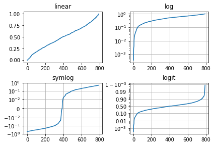

```python
%matplotlib inline

import numpy as np
import matplotlib.pyplot as plt

from matplotlib.ticker import NullFormatter  # useful for `logit` scale

# Fixing random state for reproducibility
# np.random.seed(19680801)

# make up some data in the interval ]0, 1[
y = np.random.normal(loc=0.5, scale=0.4, size=1000)
y = y[(y > 0) & (y < 1)]
y.sort()
x = np.arange(len(y))

# plot with various axes scales
plt.figure(1)

# linear
plt.subplot(221)
plt.plot(x, y)
plt.yscale('linear')
plt.title('linear')
#plt.grid(True)


# log
plt.subplot(222)
plt.plot(x, y)
plt.yscale('log') # y軸設為 log-scale
plt.title('log')
plt.grid(True)


# symmetric log:
plt.subplot(223)
plt.plot(x, y - y.mean())
plt.yscale('symlog', linthreshy=0.01)
# linthreshy:
# A single float which defines the range (-x, x), within which the plot is linear.
# This avoids having the plot go to infinity around zero.
plt.title('symlog')
plt.grid(True)

# logit : values beyond ]0, 1[ can be masked as invalid, or clipped to a number very close to 0 or 1
plt.subplot(224)
plt.plot(x, y)
plt.yscale('logit')
plt.title('logit')
plt.grid(True)

# Format the minor tick labels of the y-axis into empty strings with
# `NullFormatter`, to avoid cumbering the axis with too many labels.
plt.gca().yaxis.set_minor_formatter(NullFormatter())
# Adjust the subplot layout, because the logit one may take more space
# than usual, due to y-tick labels like "1 - 10^{-3}"
plt.subplots_adjust(top=0.92, bottom=0.08, left=0.10, right=0.95, hspace=0.4,
                    wspace=0.35)
```

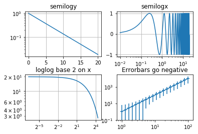

```python
%matplotlib inline

import numpy as np
import matplotlib.pyplot as plt

t = np.arange(0.01, 20.0, 0.01)

# log y axis
plt.subplot(221)
plt.semilogy(t, np.exp(-t/5.0)) # y取對數的半對數圖
plt.title('semilogy')
plt.grid(True)

# log x axis
plt.subplot(222)
plt.semilogx(t, np.sin(2*np.pi*t)) # x取對數的半對數圖
plt.title('semilogx')
plt.grid(True)

# log x and y axis
plt.subplot(223)
plt.loglog(t, 20*np.exp(-t/10.0), basex=2)
plt.grid(True)
plt.title('loglog base 2 on x')

# with errorbars: clip non-positive values
ax = plt.subplot(224)
ax.set_xscale("log", nonposx='clip')
ax.set_yscale("log", nonposy='clip')

x = 10.0**np.linspace(0.0, 2.0, 20)
y = x**2.0
plt.errorbar(x, y, xerr=0.1*x, yerr=5.0 + 0.75*y)
ax.set_ylim(ymin=0.1)
ax.set_title('Errorbars go negative')

plt.subplots_adjust(hspace=0.4)
```

## 畫Error Bar

- https://matplotlib.org/api/_as_gen/matplotlib.pyplot.errorbar.html#matplotlib.pyplot.errorbar
- https://matplotlib.org/api/_as_gen/matplotlib.axes.Axes.errorbar.html
- https://matplotlib.org/1.2.1/examples/pylab_examples/errorbar_demo.html

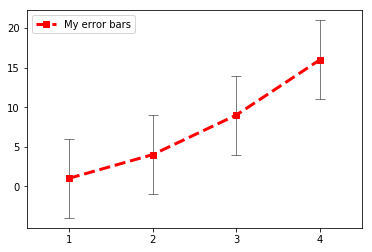

```python
%matplotlib inline

import matplotlib.pyplot as plt

line,caps,bars=plt.errorbar(
    [1,2,3,4],     # X
    [1,4,9,16],    # Y
    yerr=5,        # Y-errors
    fmt="rs--",    # format line like for plot()
    linewidth=3,   # width of plot line
    elinewidth=0.5,# width of error bar line
    ecolor='k',    # color of error bar
    capsize=5,     # cap length for error bar
    capthick=0.5   # cap thickness for error bar
    )

plt.setp(line,label="My error bars")#give label to returned line
plt.legend(numpoints=1,             #Set the number of markers in label
           loc=('upper left'))      #Set label location
plt.xlim((0.5,4.5))                 #Set X-axis limits
plt.xticks([1,2,3,4])               #get only ticks we want
plt.yticks([0,5,10,15,20])
plt.show()
```

```
Text(0.5,0.98,'Variable errorbars')
```

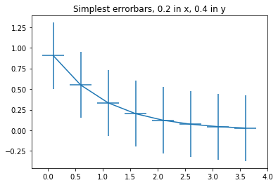

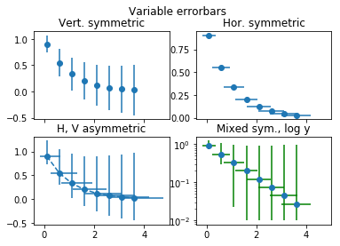

```python
%matplotlib inline

import numpy as np
import matplotlib.pyplot as plt

# data
x = np.arange(0.1, 4, 0.5)
y = np.exp(-x)

# example variable error bar values
yerr = 0.1 + 0.2*np.sqrt(x)
xerr = 0.1 + yerr

# First illustrate basic pyplot interface, using defaults where possible.
plt.figure()
plt.errorbar(x, y, xerr=0.2, yerr=0.4)
plt.title("Simplest errorbars, 0.2 in x, 0.4 in y")


# Now switch to a more OO interface to exercise more features.
fig, axs = plt.subplots(nrows=2, ncols=2, sharex=True)
ax = axs[0,0]
ax.errorbar(x, y, yerr=yerr, fmt='o')
ax.set_title('Vert. symmetric')

# With 4 subplots, reduce the number of axis ticks to avoid crowding.
ax.locator_params(nbins=4)

ax = axs[0,1]
ax.errorbar(x, y, xerr=xerr, fmt='o')
ax.set_title('Hor. symmetric')

# 非對稱型的error，用 array的2個變數指定
ax = axs[1,0]
ax.errorbar(x, y, yerr=[yerr, 2*yerr], xerr=[xerr, 2*xerr], fmt='--o')
ax.set_title('H, V asymmetric')

ax = axs[1,1]
ax.set_yscale('log')
# Here we have to be careful to keep all y values positive:
ylower = np.maximum(1e-2, y - yerr)
yerr_lower = y - ylower

ax.errorbar(x, y, yerr=[yerr_lower, 2*yerr], xerr=xerr,
            fmt='o', ecolor='g', capthick=2)
ax.set_title('Mixed sym., log y')

fig.suptitle('Variable errorbars')
```

## Errorbar Limit

```
(-1, 10)
```

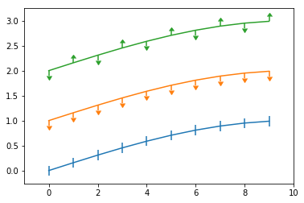

```python
%matplotlib inline

import numpy as np
import matplotlib.pyplot as plt

fig = plt.figure(0)
x = np.arange(10.0)
y = np.sin(np.arange(10.0) / 20.0 * np.pi)
plt.errorbar(x, y, yerr=0.1)

y = np.sin(np.arange(10.0) / 20.0 * np.pi) + 1
plt.errorbar(x, y, yerr=0.1, uplims=True)    # 設定upper limit


y = np.sin(np.arange(10.0) / 20.0 * np.pi) + 2
upperlimits = np.array([1, 0] * 5)
lowerlimits = np.array([0, 1] * 5)
plt.errorbar(x, y, yerr=0.1, uplims=upperlimits, lolims=lowerlimits)

plt.xlim(-1, 10)
```

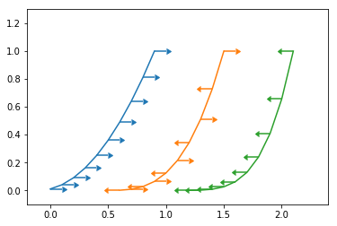

```python
%matplotlib inline

import numpy as np
import matplotlib.pyplot as plt

fig = plt.figure(1)
x = np.arange(10.0) / 10.0
y = (x + 0.1)**2

plt.errorbar(x, y, xerr=0.1, xlolims=True)
y = (x + 0.1)**3

plt.errorbar(x + 0.6, y, xerr=0.1, xuplims=upperlimits, xlolims=lowerlimits)

y = (x + 0.1)**4
plt.errorbar(x + 1.2, y, xerr=0.1, xuplims=True)

plt.xlim(-0.2, 2.4)
plt.ylim(-0.1, 1.3)

plt.show()
```

# text 文字操作

- https://matplotlib.org/api/text_api.html

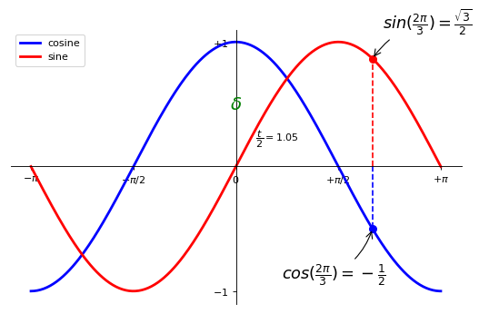

```python
%matplotlib inline

import numpy as np
import matplotlib.pyplot as plt

plt.figure(figsize=(8, 5), dpi=80)

plt.subplot(111)
X = np.linspace(-np.pi, np.pi, 256,endpoint=True)
C = np.cos(X)
S = np.sin(X)
plt.plot(X, C, color="blue", linewidth=2.5, linestyle="-", label="cosine")
plt.plot(X, S, color="red", linewidth=2.5, linestyle="-", label="sine")

# 設定軸的型態
ax = plt.gca()
ax.spines['right'].set_color('none')
ax.spines['top'].set_color('none')
ax.xaxis.set_ticks_position('bottom')
ax.spines['bottom'].set_position(('data',0))
ax.yaxis.set_ticks_position('left')
ax.spines['left'].set_position(('data',0))

plt.xlim(X.min() * 1.1, X.max() * 1.1)
plt.xticks([-np.pi, -np.pi/2, 0, np.pi/2, np.pi], [r'$-\pi$', r'$-\pi/2$', r'$0$', r'$+\pi/2$', r'$+\pi$'])

plt.ylim(C.min() * 1.1, C.max() * 1.1)
plt.yticks([-1, +1], [r'$-1$', r'$+1$'])



t = 2*np.pi/3

# 畫線：(t,0) 到 (t, cos(t)) ，點：(t, cos(t))
plt.plot([t, t], [0, np.cos(t)], color='blue', linewidth=1.5, linestyle="--")
plt.scatter([t, ], [np.cos(t), ], 50, color='blue')

# 文字表示：
plt.annotate(r'$sin(\frac{2\pi}{3})=\frac{\sqrt{3}}{2}$', xy=(t, np.sin(t)),
             xycoords='data', xytext=(+10, +30), textcoords='offset points', fontsize=16,
             arrowprops=dict(arrowstyle="->", connectionstyle="arc3,rad=.2"))


plt.plot([t, t], [0, np.sin(t)], color='red', linewidth=1.5, linestyle="--")
plt.scatter([t, ], [np.sin(t), ], 50, color='red')
plt.annotate(r'$cos(\frac{2\pi}{3})=-\frac{1}{2}$', xy=(t, np.cos(t)),
             xycoords='data', xytext=(-90, -50), textcoords='offset points',fontsize=16,
             arrowprops=dict(arrowstyle="->", connectionstyle="arc3,rad=.2"))

# 或用 text
ax.text(0, 0.5, r'$\delta$',horizontalalignment='center', verticalalignment='center', fontsize=18, color='green')

#text內容顯示變數
ax.text(0.3,0.2, r'$\dfrac{t}{2}=%.2f $'  %(t/2))

plt.legend(loc='upper left')
```

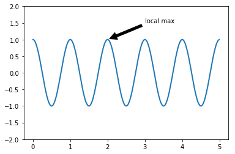

```python
import numpy as np
import matplotlib.pyplot as plt

ax = plt.subplot(111)

t = np.arange(0.0, 5.0, 0.01)
s = np.cos(2*np.pi*t)
line, = plt.plot(t, s, lw=2)

plt.annotate('local max', xy=(2, 1), xytext=(3, 1.5),
            arrowprops=dict(facecolor='black', shrink=0.05),
            )

plt.ylim(-2,2)
plt.show()
```

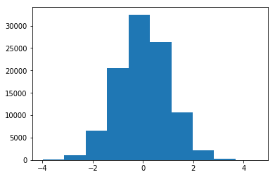

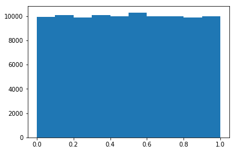

```python
%matplotlib inline

import numpy as np
import matplotlib.pyplot as plt

normal_samples = np.random.normal(size = 100000)   #  100000 組標準常態分配（平均值為 0，標準差為 1 的常態分配）隨機變數
uniform_samples = np.random.uniform(size = 100000) #  100000 組介於 0 與 1 之間均勻分配隨機變數

plt.figure()
plt.hist(normal_samples)

plt.figure()
plt.hist(uniform_samples)
```

`matplotlib.pyplot.hist(x, bins=None, range=None, density=None, weights=None, cumulative=False, bottom=None, histtype='bar', align='mid', orientation='vertical', rwidth=None, log=False, color=None, label=None, stacked=False, normed=None, hold=None, data=None, **kwargs)`

### bins : integer or sequence or ‘auto’, optional

If an integer is given, bins + 1 bin edges are calculated and returned, consistent with numpy.histogram().

If bins is a sequence, gives bin edges, including left edge of first bin and right edge of last bin. In this case, bins is returned unmodified.

All but the last (righthand-most) bin is half-open. In other words, if bins is: [1, 2, 3, 4] then the first bin is [1, 2) (including 1, but excluding 2) and the second [2, 3). The last bin, however, is [3, 4], which includes 4.

Unequally spaced bins are supported if bins is a sequence.

### density : boolean, optional

If True, the first element of the return tuple will be the counts normalized to form a probability density, i.e., the area (or integral) under the histogram will sum to 1. This is achieved by dividing the count by the number of observations times the bin width and not dividing by the total number of observations. If stacked is also True, the sum of the histograms is normalized to

1.Default is None for both normed and density. If either is set, then that value will be used. If neither are set, then the args will be treated as False.

If both density and normed are set an error is raised.

### cumulative : boolean, optional

If True, then a histogram is computed where each bin gives the counts in that bin plus all bins for smaller values. The last bin gives the total number of datapoints. If normed or density is also True then the histogram is normalized such that the last bin equals 1. If cumulative evaluates to less than 0 (e.g., -1), the direction of accumulation is reversed. In this case, if normed and/or density is also True, then the histogram is normalized such that the first bin equals 1.

Default is False

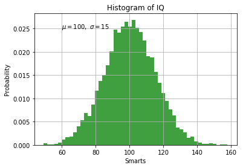

```python
%matplotlib inline

import numpy as np
import matplotlib.pyplot as plt

mu, sigma = 100, 15
x = mu + sigma * np.random.randn(10000)

# the histogram of the data
n, bins, patches = plt.hist(x, 50, density=1, facecolor='g', alpha=0.75)


plt.xlabel('Smarts')
plt.ylabel('Probability')
plt.title('Histogram of IQ')

plt.text(60, .025, r'$\mu=100,\ \sigma=15$')
plt.grid(True)
```

```
Text(0.5,0,'X axis')
```

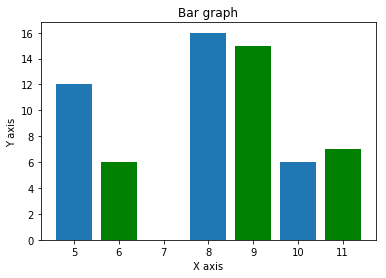

```python
%matplotlib inline

from matplotlib import pyplot as plt

x =  [5,8,10]
y =  [12,16,6]
x2 =  [6,9,11]
y2 =  [6,15,7]

plt.bar(x, y, align =  'center')
plt.bar(x2, y2, color =  'g', align =  'center')

plt.title('Bar graph')
plt.ylabel('Y axis')
plt.xlabel('X axis')
```

```
<BarContainer object of 3 artists>
```

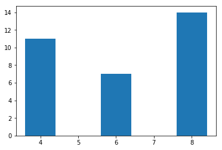

```python
%matplotlib inline

from collections import Counter
import matplotlib.pyplot as plt
import numpy as np

cyl = [6 ,6 ,4 ,6 ,8 ,6 ,8 ,4 ,4 ,6 ,6 ,8 ,8 ,8 ,8 ,8 ,8 ,4 ,4 ,4 ,4 ,8 ,8 ,8 ,8 ,4 ,4 ,4 ,8 ,6 ,8 ,4]

indexes, values = zip(*Counter(cyl).items())
width = 1

plt.bar(indexes, values)
```

```
([], <a list of 0 Text yticklabel objects>)
```

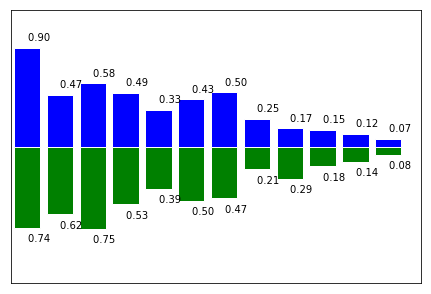

```python
%matplotlib inline

import numpy as np
import matplotlib.pyplot as plt

n = 12
X = np.arange(n)
Y1 = (1 - X / float(n)) * np.random.uniform(0.5, 1.0, n)
Y2 = (1 - X / float(n)) * np.random.uniform(0.5, 1.0, n)

plt.axes([0.025, 0.025, 0.95, 0.95])

plt.bar(X, +Y1, facecolor='blue', edgecolor='white')
plt.bar(X, -Y2, facecolor='green', edgecolor='white')

for x, y in zip(X, Y1):
    plt.text(x + 0.4, y + 0.05, '%.2f ' % y, ha='center', va= 'bottom')
for x, y in zip(X, Y2):
    plt.text(x + 0.4, -y - 0.05, '%.2f ' % y, ha='center', va= 'top')

plt.xlim(-.5, n)
plt.xticks(())
plt.ylim(-1.25, 1.25)
plt.yticks(())
```

```
{'boxes': [<matplotlib.lines.Line2D at 0x250f2732748>],
 'caps': [<matplotlib.lines.Line2D at 0x250f2728240>,
 'fliers': [<matplotlib.lines.Line2D at 0x250f273dba8>],
 'means': [],
 'medians': [<matplotlib.lines.Line2D at 0x250f2728e10>],
 'whiskers': [<matplotlib.lines.Line2D at 0x250f2732898>,
```

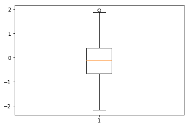

```python
%matplotlib inline

import numpy as np
import matplotlib.pyplot as plt

normal_samples = np.random.normal(size = 100) # 生成 100000 組標準常態分配（平均值為 0，標準差為 1 的常態分配）隨機變數

plt.boxplot(normal_samples)

# Make a box and whisker plot for each column of x or each vector in sequence x.
# The box extends from the lower to upper quartile values of the data, with a line at the median.
# The whiskers extend from the box to show the range of the data. Flier points are those past the end of the whiskers
```

```
([], <a list of 0 Text yticklabel objects>)
```

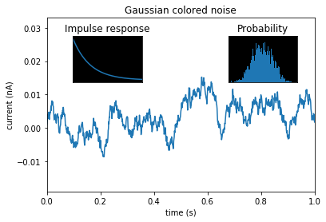

```python
%matplotlib inline
import matplotlib.pyplot as plt
import numpy as np

# Fixing random state for reproducibility
np.random.seed(19680801)


# create some data to use for the plot
dt = 0.001
t = np.arange(0.0, 10.0, dt)
r = np.exp(-t[:1000] / 0.05)  # impulse response
x = np.random.randn(len(t))
s = np.convolve(x, r)[:len(x)] * dt  # colored noise

# the main axes is subplot(111) by default
plt.plot(t, s)
plt.axis([0, 1, 1.1 * np.min(s), 2 * np.max(s)])
plt.xlabel('time (s)')
plt.ylabel('current (nA)')
plt.title('Gaussian colored noise')

# this is an inset axes over the main axes
a = plt.axes([.65, .6, .2, .2], facecolor='k')
n, bins, patches = plt.hist(s, 400, density=True)
plt.title('Probability')
plt.xticks([])
plt.yticks([])

# this is another inset axes over the main axes
a = plt.axes([0.2, 0.6, .2, .2], facecolor='k')
plt.plot(t[:len(r)], r)
plt.title('Impulse response')
plt.xlim(0, 0.2)
plt.xticks([])
plt.yticks([])
```